# Quantitative Sciences

Mingzhu Ye

## Part I Questions

### 1.When presented with a new dataset or database, what steps do you generally take to evaluate it prior to working with it?

### 2.Based on the information provided above and the attached dataset, what 3 questions would you like to understand prior to conducting any analysis of the data?

### 3.How would you prep the dataset provided for analysis? Please list steps taken and provide code used to prep the tables for analysis.

## Part II Questions

### 1. Average time elapsed between initial diagnosis and first treatment

This is the quick view of merged results:

```r
head(subdf2, 5)
```

```
##   patient_id date_diff  gender
## 1      5402v     17011    male
## 2     a3169y     27786    male
## 3     a6230g     18385  female
## 4     a6991u     11894 unknown
## 5     a7481m     26457  female
```

### Conclusion

The averaged time between a patient’s initial diagnose and first treatment is 14025.56 days. And the average time differs in male and female, separately 12693.5 days and 15114.65 days.

### 2. Patients on drug nivolumab from 2012-2016

### Conclusion

There were totally 62 unique patients on drug “nibolumab” during year 2012-2016. While, some patients made multiple orders for the drug “nibolumab”, so there were totally 100 unique orders for drug “nibolumab” during year 2012-2016.

### 3. Add new stratification to dataset demographics

This is the quick view of the demographics with stratification rules added:

```r
head(demographics2,3)
```

```
##   patient_id gender age      race Cancer_Risk_Level
## 1     h9993d female  69 NON_WHITE         High_Risk
## 2     w9986a female  46     WHITE          Low_Risk
## 3     n9925d female  84 NON_WHITE         High_Risk
```

This is the categorical table with risk level as category:

```r
table(demographics2$Cancer_Risk_Level)
```

```
##
##           High_Risk High_to_Medium_Risk            Low_Risk
##                  33                   1                  40
##         Medium_Risk  Medium_to_Low_Risk
##                  24                   1
```

### Conclusion

Among 99 unique patients, 40 are of Low_Risk, 33 are of High_Risk, 24 are of Medium_Risk, 1 is High_to_Medium_Risk and 1 is Medium_to_Low_Risk.

### 4. How drug prevalence has changed over time

**Assumption1**  
Due to the small sample size, a ggplot of drug prevalence based on year has been created. This year-result may be more significant than results based on days or months.

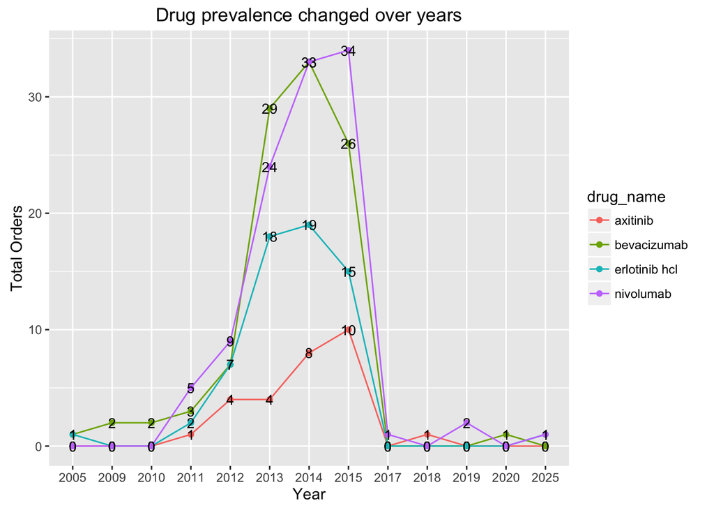

**Assumption2**  
As observed from plot1, there are drugs administered in the future, namely 2017, 2018, 2019, 2020 and 2025. Since the medical researcher may only want to look history data, therefore I also created a plot2 using drug data during 2005-2015.

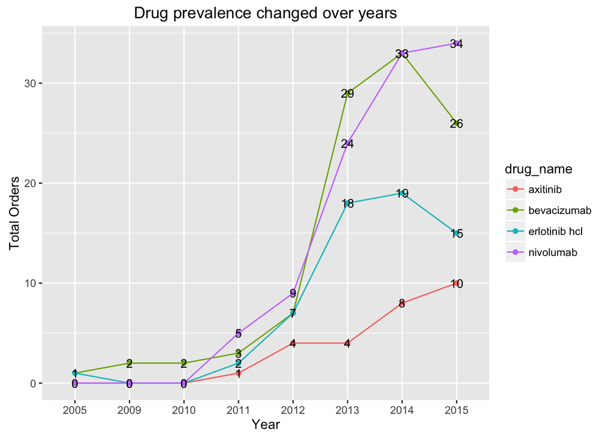